# Probability & Distributions

Matthew Talluto

02.05.2022

# Detecting Zombies

*Intuitively*: the test is good, so the probability that a positive testing individual is a zombie should be high  
(many people answer 99%, given the false positive rate of 1%).

*Unintuitively*: zombies are very rare, so when testing many people randomly, many tests will be false positives.

**Desired outcome**: $pr(Z | T)$  
(if I test positive, what is the probability I am a zombie?)

# Detecting Zombies

- Consider a population of a million people, in a contingency table.

**Desired outcome**: $pr(Z | T)$  
(if I test positive, what is the probability I am a zombie?)

|  | Test+ | Test- | Sum |
| --- | --- | --- | --- |
| Zombie | – | – | – |
| Not Zombie | – | – | – |
| Sum | – | – | 1,000,000 |

# Detecting Zombies

- Consider a population of a million people, in a contingency table.
- 0.1% of the population is infected with a parasite that will turn them into zombies (1000 zombies)

**Desired outcome**: $pr(Z | T)$  
(if I test positive, what is the probability I am a zombie?)

|  | Test+ | Test- | Sum |
| --- | --- | --- | --- |
| Zombie | – | – | 1,000 |
| Not Zombie | – | – | 999,000 |
| Sum | – | – | 1,000,000 |

# Detecting Zombies

- Consider a population of a million people, in a contingency table.
- 0.1% of the population is infected with a parasite that will turn them into zombies (1000 zombies)
- 0.5% of zombies will falsely test negative (false negative rate): 5 negative zombies, 995 positive ones

**Desired outcome**: $pr(Z | T)$  
(if I test positive, what is the probability I am a zombie?)

|  | Test+ | Test- | Sum |
| --- | --- | --- | --- |
| Zombie | 995 | 5 | 1,000 |
| Not Zombie | – | – | 999,000 |
| Sum | – | – | 1,000,000 |

# Detecting Zombies

- Consider a population of a million people, in a contingency table.
- 0.1% of the population is infected with a parasite that will turn them into zombies (1000 zombies)
- 0.5% of zombies will falsely test negative (false negative rate): 5 negative zombies, 995 positive ones
- 1% of non-zombies will falsely test positive: 9990 positive normals, 989010 negative normals

**Desired outcome**: $pr(Z | T)$  
(if I test positive, what is the probability I am a zombie?)

|  | Test+ | Test- | Sum |
| --- | --- | --- | --- |
| Zombie | 995 | 5 | 1,000 |
| Not Zombie | 9,990 | 989,010 | 999,000 |
| Sum | 10,985 | 989,015 | 1,000,000 |

# Detecting Zombies

- Consider a population of a million people, in a contingency table.
- 0.1% of the population is infected with a parasite that will turn them into zombies (1000 zombies)
- 0.5% of zombies will falsely test negative (false negative rate): 5 negative zombies, 995 positive ones
- 1% of non-zombies will falsely test positive: 9990 positive normals, 989010 negative normals
- Positive test is a given; thus only 995 of 10985 positive tests are zombies, or 9.06%

**Desired outcome**: $pr(Z | T)$  
(if I test positive, what is the probability I am a zombie?)

|  | Test+ | Test- | Sum |
| --- | --- | --- | --- |
| Zombie | 995 |  |  |
| Not Zombie | 9,990 |  |  |
| Sum | 10,985 |  |  |

# Detecting Zombies

- First translate numbers to probabilities

> 0.1% of the population is infected with a parasite that will turn them into zombies.
- $pr(Z) = 0.001$
- This is the **prevalence** of zombies or the **prior probability** that a randomly selected person is a zombie

**Desired outcome**: $pr(Z | T)$  
(if I test positive, what is the probability I am a zombie?)

# Detecting Zombies

- First translate numbers to probabilities

> 0.1% of the population is infected with a parasite that will turn them into zombies.
- $pr(Z) = 0.001$
- This is the **prevalence** of zombies or the **prior probability** that a randomly selected person is a zombie

> *false negative rate* = 0.5%  
> *false positive rate* = 1%
- $pr(T' | Z) = 0.005$
- $pr(T | Z') = 0.01$

**Desired outcome**: $pr(Z | T)$  
(if I test positive, what is the probability I am a zombie?)

# Detecting Zombies

- Use probability rules to find other easy unknowns
- True positive rate:

$pr(T | Z) = 1 - pr(T' | Z) = 1 - 0.005 = 0.995$

- True negative rate:

$pr(T' | Z') = 1 - pr(T | Z') = 1 - 0.01 = 0.99$

**Desired outcome**: $pr(Z | T)$  
(if I test positive, what is the probability I am a zombie?)

**Given**

$pr(Z) = 0.001$

$pr(T' | Z) = 0.005$

$pr(T | Z') = 0.01$

# Detecting Zombies

- Use the product rule to compute the **joint probability**

$pr(Z,T) = pr(T|Z)pr(Z) = 0.995 \times 0.001 = 0.000995$

- The product rule is reversible:
- $pr(Z,T) = pr(T|Z)pr(Z) = pr(Z|T)pr(T)$
- Simple algebra can solve for the quantity we desire

$$pr(Z|T) = \frac{pr(T|Z)pr(Z)}{pr(T)}$$

> (Bayes’ Theorem)

**Desired outcome**: $pr(Z | T)$  
(if I test positive, what is the probability I am a zombie?)

**Given**

$pr(Z) = 0.001$

$pr(T' | Z) = 0.005$

$pr(T | Z') = 0.01$

**Known**

$pr(T | Z) = 0.995$

$pr(T' | Z') = 0.99$

# Detecting Zombies

$$pr(Z|T) = \frac{pr(T|Z)pr(Z)}{pr(T)}$$

- We are missing a single value: $pr(T)$
- There are two ways to get a positive test:
- positive, and a zombie: $pr(Z,T)$
- positive, and not a zombie: $pr(Z',T)$

**Desired outcome**: $pr(Z | T)$  
(if I test positive, what is the probability I am a zombie?)

**Given**

$pr(Z) = 0.001$

$pr(T'| Z) = 0.005$

$pr(T | Z') = 0.01$

**Known**

$pr(T | Z) = 0.995$

$pr(T' | Z') = 0.99$

$pr(Z,T) = 0.000995$

# Detecting Zombies

$$\begin{aligned}
pr(Z|T) & = \frac{pr(T|Z)pr(Z)}{pr(T)} \\
& = \frac{0.995 \times 0.001}{0.010985} \\
& = 0.0906
\end{aligned}$$

**Desired outcome**: $pr(Z | T)$  
(if I test positive, what is the probability I am a zombie?)

**Given**

$pr(Z) = 0.001$

$pr(T' | Z) = 0.005$

$pr(T | Z') = 0.01$

**Known**

$pr(T | Z) = 0.995$

$pr(T' | Z') = 0.99$

$pr(Z,T) = 0.000995$

$pr(T) = 0.010985$

# Signal detection problems

- the zombie example is cute, but it is a real biological problem
- “True” state is often hidden, we have an imperfect signal

# Signal detection problems

- the zombie example is cute, but it is a real biological problem
- “True” state is often hidden, we have an imperfect signal
- Desired outcome: presence/absence of endangered species
- Imperfect indicator (expert observation)
- Desire to know $pr(present | observed)$

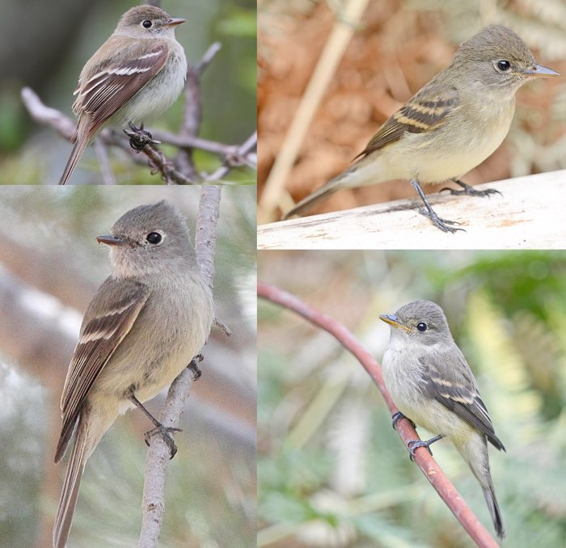

|  | Observed | Not Observed |
| --- | --- | --- |
| Present | ? | ? |
| Absent | ? | ? |

# Product rule => Chain rule

$$\begin{aligned}
pr(A,B) & = pr(A|B)pr(B) \\
\end{aligned}$$

# Product rule => Chain rule

$$\begin{aligned}
pr(A,B) & = pr(A|B)pr(B) \\
\end{aligned}$$

$$\begin{aligned}
pr(A,B,C) & = pr(A|B,C)pr(B,C) \\
& = pr(A|B,C)pr(B|C)pr(C)
\end{aligned}$$

# Product rule => Chain rule

$$\begin{aligned}
pr(A,B) & = pr(A|B)pr(B) \\
\end{aligned}$$

$$\begin{aligned}
pr(A,B,C) & = pr(A|B,C)pr(B,C) \\
& = pr(A|B,C)pr(B|C)pr(C)
\end{aligned}$$

$$\begin{aligned}
pr(\bigcap_{k=1}^{n} A_k) & = pr(A_n | \bigcap_{k=1}^{n-1} A_k )pr(\bigcap_{k=1}^{n-1} A_k) \\
& =\prod_{k=1}^{n}pr(A_k | \bigcap_{j=1}^{k-1}A_j)
\end{aligned}$$

# Probability Concepts/Rules

- **Marginal probability**: $pr(A)$
- **Conditional probability**: $pr(A|B)$
- **Joint probability**: $pr(A,B) = pr(A \cap B)$

# Probability Concepts/Rules

- **Marginal probability**: $pr(A)$
- **Conditional probability**: $pr(A|B)$
- **Joint probability**: $pr(A,B) = pr(A \cap B)$
- **Complementary rule**: $pr(A') = 1 - pr(A)$
- **Addition rule**: $pr(A \cup B) = pr(A) + pr(B) - pr(A \cap B)$
  - For *disjoint* events: $pr(A \cap B) = 0$
- **Product rule**: $pr(A,B) = pr(A|B)pr(B)$
  - For *independent* events: $pr(A|B) = pr(A)$
- **Chain rule**: $pr(\bigcap_{k=1}^{n} A_k) =\prod_{k=1}^{n}pr(A_k | \bigcap_{j=1}^{k-1}A_j)$
- **Bayes’ theorem**: $pr(B|A) = \frac{pr(A|B)pr(B)}{pr(A)}$

# Probability distributions

- Our test gets more useful if $pr(Z) = 0.3$
- Testing one person randomly taken from a (effectively) infinite population, 30% of the time the person is a zombie
- Trivially, doing this 10 times would result in 3 zombies, 7 normals.
- But the sampling is random! Sometimes we will see 4 zombies, sometimes 2, etc. How often?

# Probability distributions

- Generally, what is the probability of $k$ zombies when we sample $n$ people?

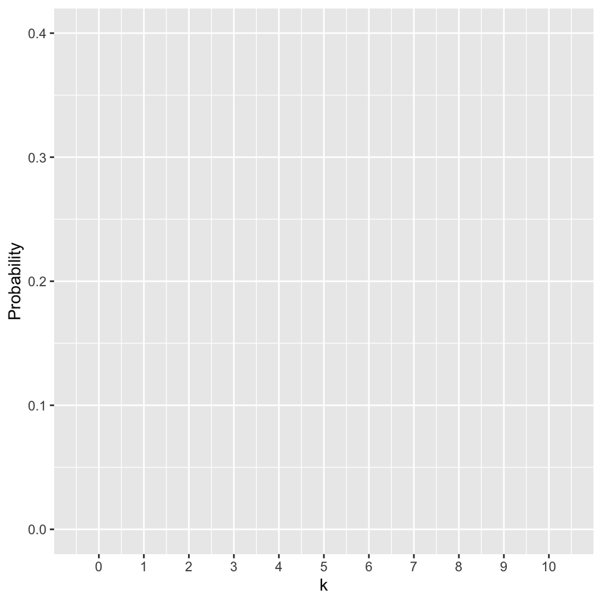

# Probability distributions

- Generally, what is the probability of $k$ zombies when we sample $n$ people?
- There is only one possible way to have 10 normal people:

$$\begin{align}
pr(k = 0 | n = 10, p = 0.3) & = (0.7 \times \ldots 0.7) \\
& = 0.7^{10} \\
& \approx 0.028 \\
\end{align}$$

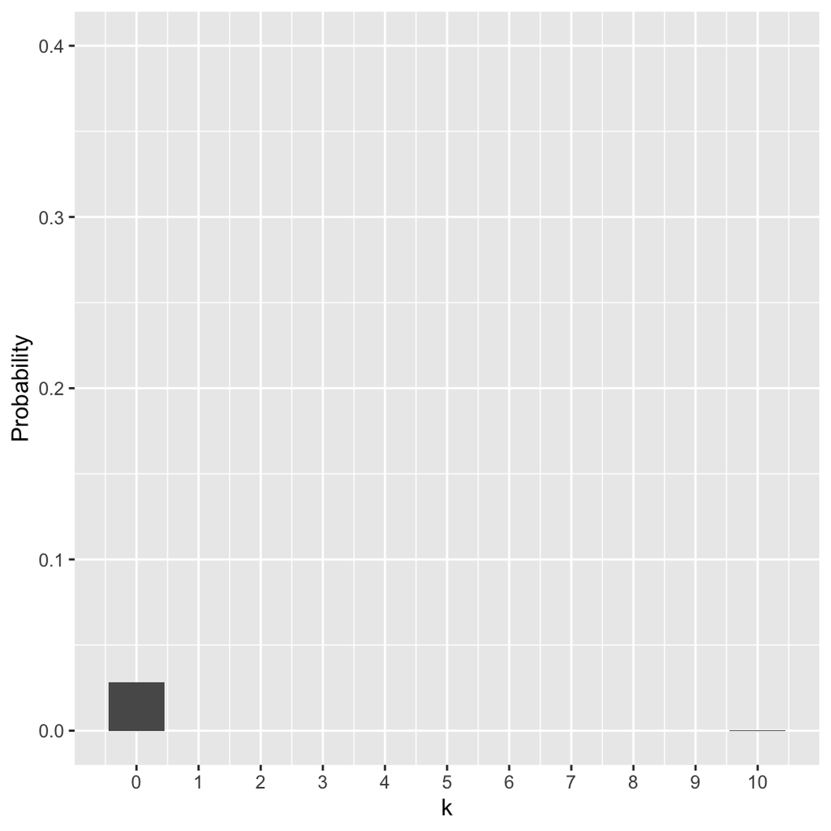

# Probability distributions

- Generally, what is the probability of $k$ zombies when we sample $n$ people?
- There are 10 ways to have exactly one zombie (*why?*).
- The probability of *one* of those ways:

$$pr(Z_1,Z'_{2..10}) = 0.3 \times0.7^9 \approx 0.012$$

- Using the **addition rule**:

$$pr(k=1|n=10,p=0.3) = 10 \times 0.3 \times0.7^9 \approx 0.121$$

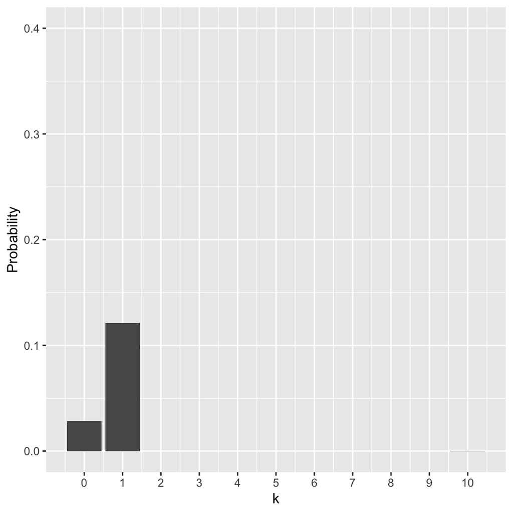

# Probability distributions

- Generally, what is the probability of $k$ zombies when we sample $n$ people?
- Generalising, the the probability that we will get any one result (i.e., order matters):

$$pr(Z_{a}, Z'_{a'}) = p^k(1 - p)^{(n - k)}$$

- The number of different ways to achieve a given result is the **binomial function** (“n choose k”)
- It follows:

$$pr(k|n,p) = {n \choose k} p^k(1-p)^{(n-k)}$$

```r
choose(n = 10, k = 0:10)
```

```
##  [1]   1  10  45 120 210 252 210 120  45  10   1
```

```r
round(dbinom(0:10, 10, 0.3), 3)
```

```
##  [1] 0.028 0.121 0.233 0.267 0.200 0.103 0.037 0.009 0.001 0.000 0.000
```

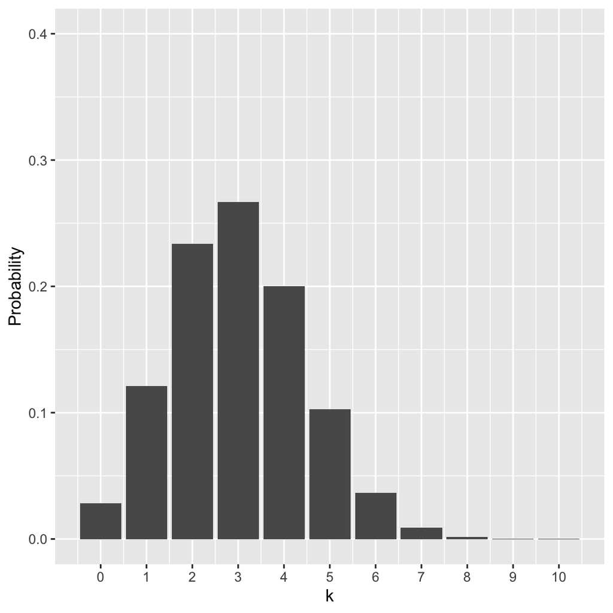

# Binomial distribution

- This is the **probability mass function (PMF)** of the **binomial distribution** (`dbinom` in R)
  $$pr(k|n,p) = {n \choose k} p^k(1-p)^{(n-k)}$$
- What is the probability of observing $k$ events out of $n$ independent trials, when $pr(k) = p$?

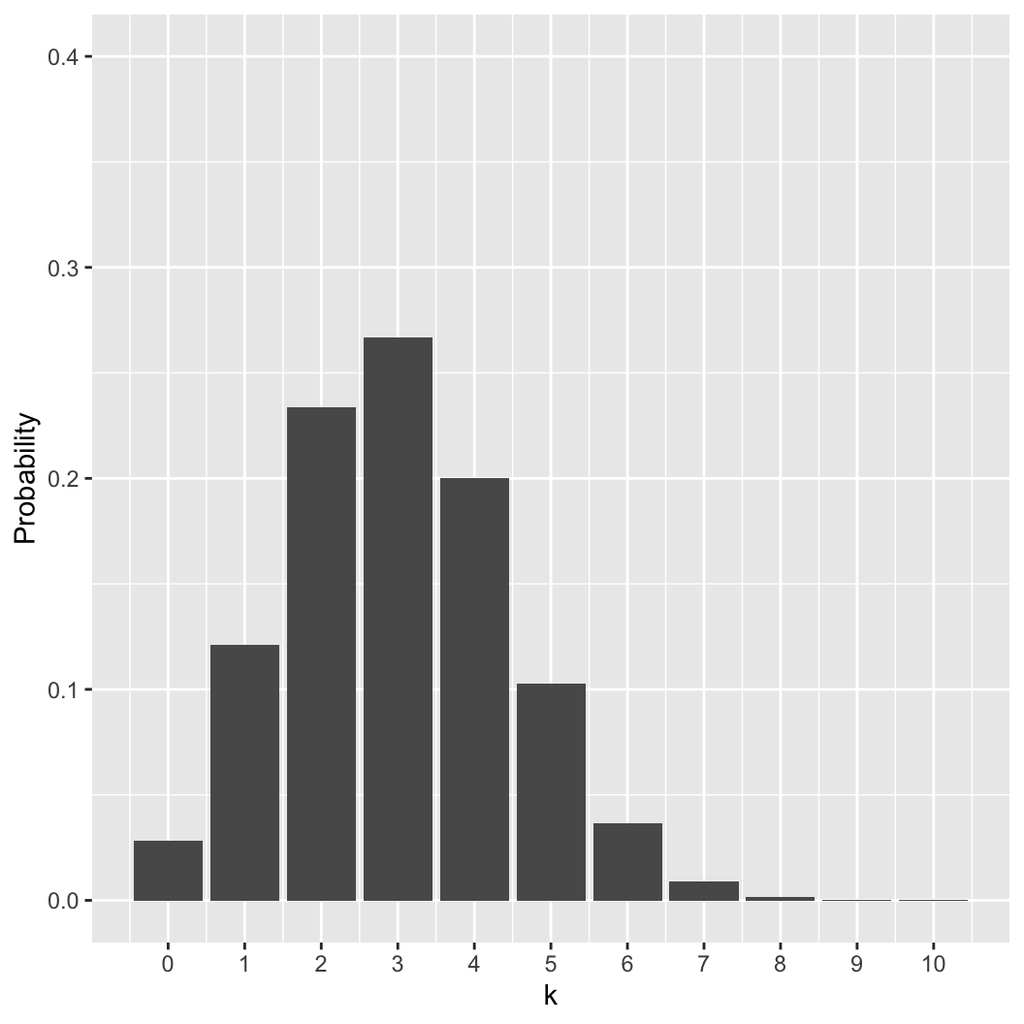

# Binomial distribution

- This is the **probability mass function (PMF)** of the **binomial distribution** (`dbinom` in R)
  $$pr(k|n,p) = {n \choose k} p^k(1-p)^{(n-k)}$$
- What is the probability of observing $k$ events out of $n$ independent trials, when $pr(k) = p$?
- What is the probability of observing $\le k$ events? **Cumulative distribution function (CDF)**

$$pr(X \le k|n,p) = \sum_{i=0}^{k} {n \choose i}p^i(1-p)^{(n-i)}$$

```r
k = 0:10
y = pbinom(k, 10, 0.3)
round(y, 3)
```

```
##  [1] 0.028 0.149 0.383 0.650 0.850 0.953 0.989 0.998 1.000 1.000 1.000
```

```r
round(sum(dbinom(0:2,10,0.3)), 3)
```

```
## [1] 0.383
```

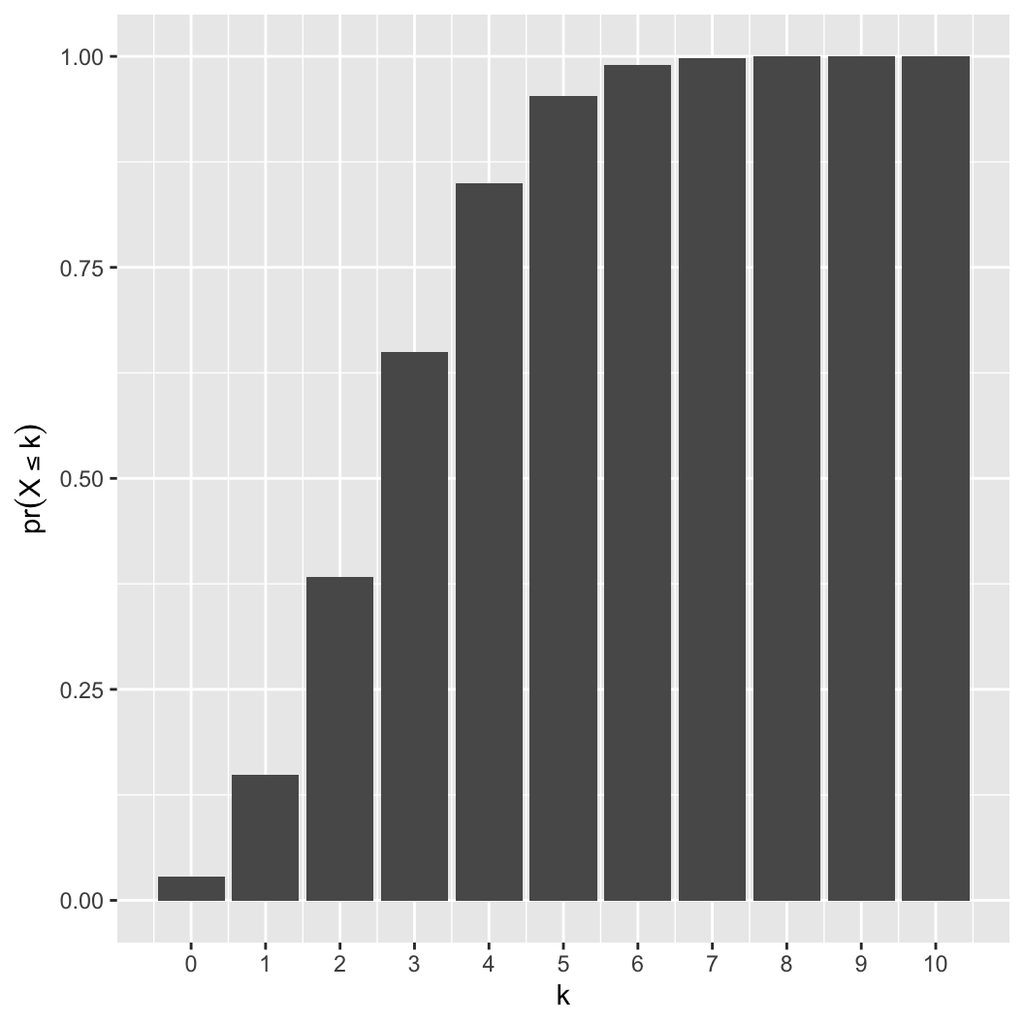

# Poisson distribution

- Probability of observing $x$ events in a fixed time/space given a rate of $\lambda$
- Limit of binomial as $n \rightarrow \infty$ and $p \rightarrow 0$
- mean = variance = $\lambda$
- Commonly used for “simple” counts

```r
lam = 5
pois_dat = data.frame(x = 0:20)
pois_dat$pmf = dpois(pois_dat$x, lam)
pois_dat$cdf = ppois(pois_dat$x, lam)
```

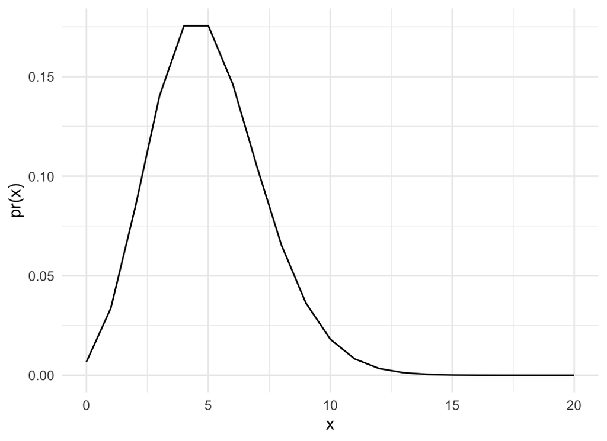

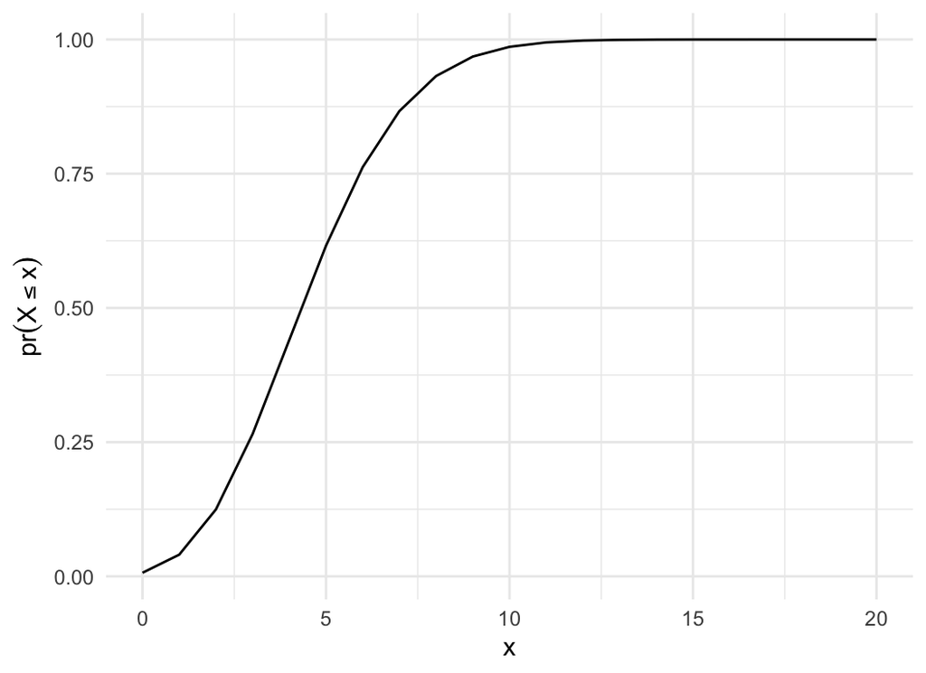

# Poisson distribution

- Probability of observing $x$ events in a fixed time/space given a rate of $\lambda$
- Limit of binomial as $n \rightarrow \infty$ and $p \rightarrow 0$
- mean = variance = $\lambda$
- Commonly used for “simple” counts

```r
lam = c(0.5, 2, 5, 20)
pois_dat = expand.grid(x=0:50, lam=lam)
pois_dat$pmf = dpois(pois_dat$x, pois_dat$lam)
pois_dat$cdf = ppois(pois_dat$x, pois_dat$lam)
```

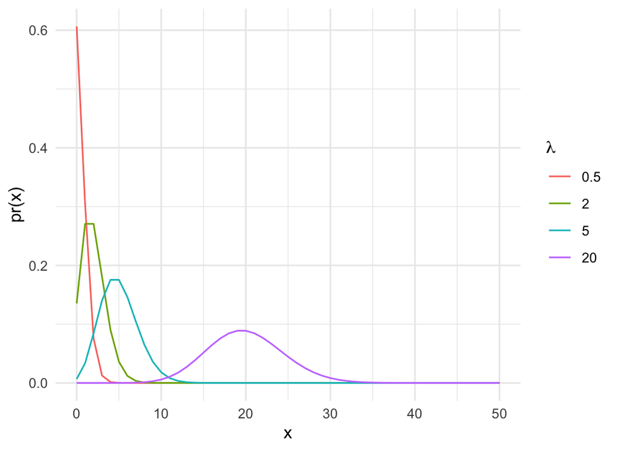

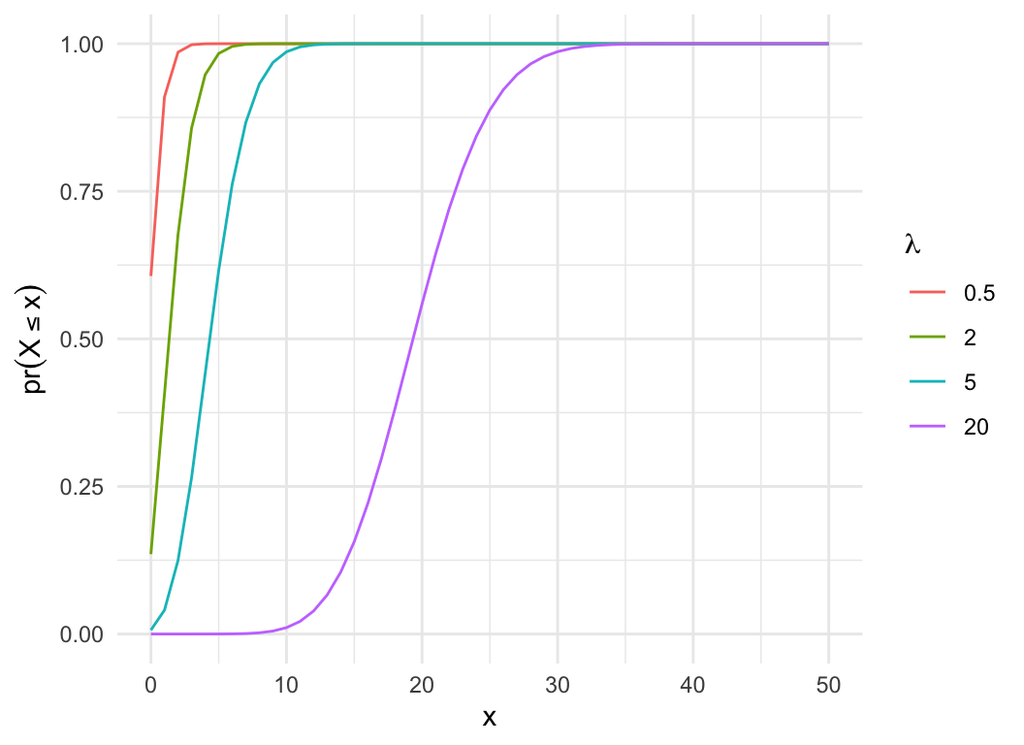

# Negative binomial distribution

- Choose one person from the population where $p = pr(Z) = 0.3$. Is she/he a zombie? Repeat…
- How many non-zombies will I observe before I find $r$ zombies?
- In biology, often parameterized by mean ($\mu$) and dispersion ($r$) instead of size ($r$) and probability ($p$), used for “overdispersed” counts

$$\mu = \frac{pr}{1-p}$$
$$s^2 = \mu + \frac{\mu^2}{r}$$

```r
dat = expand.grid(x = 0:60, mu = c(10,20), size = c(5, 2))
dat$pmf = with(dat, dnbinom(x, mu=mu, size=size))
dat$cdf = with(dat, pnbinom(x, mu=mu, size=size))
```

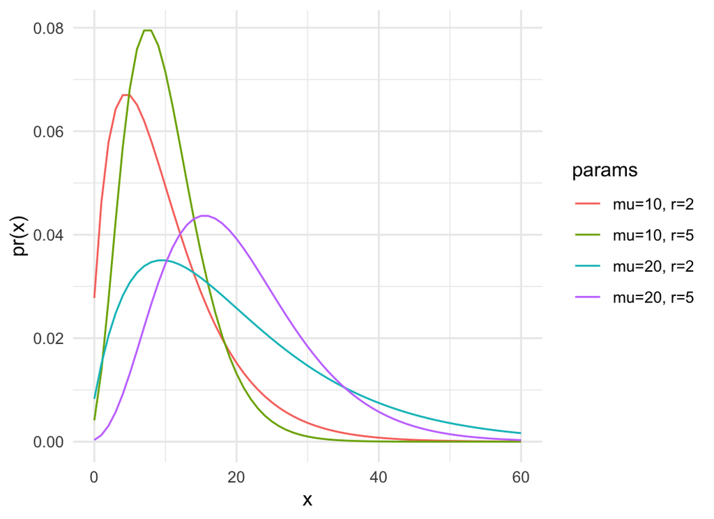

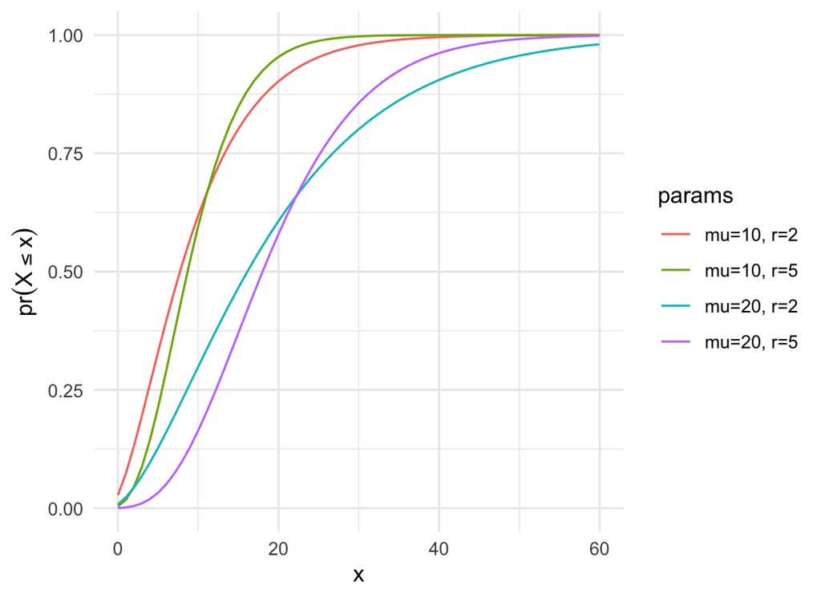

# Exponential distribution

- Complement to Poisson, models the time between events of a Poisson process with rate $\lambda$
- $\mu = \frac{1}{\lambda}$
- Continuous, defined on $(0, \infty)$

```r
lam = c(0.5, 2, 5, 20)
dat = expand.grid(x=seq(0,15, length.out=100), lam=lam)
dat$pdf = dexp(dat$x, dat$lam)
dat$cdf = pexp(dat$x, dat$lam)
```

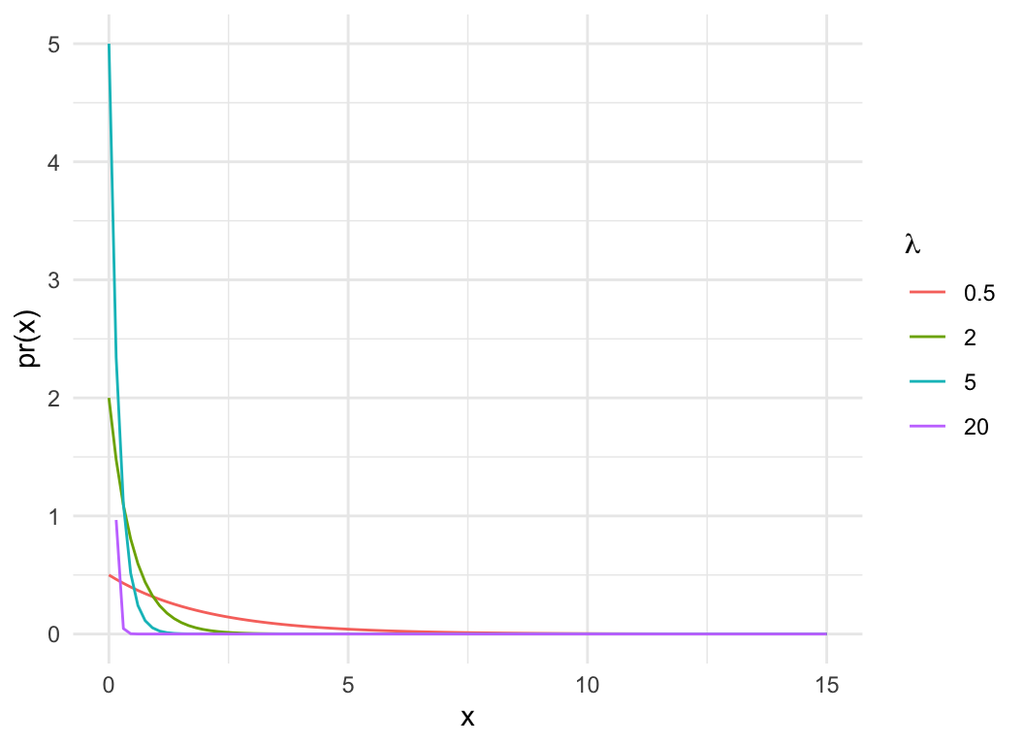

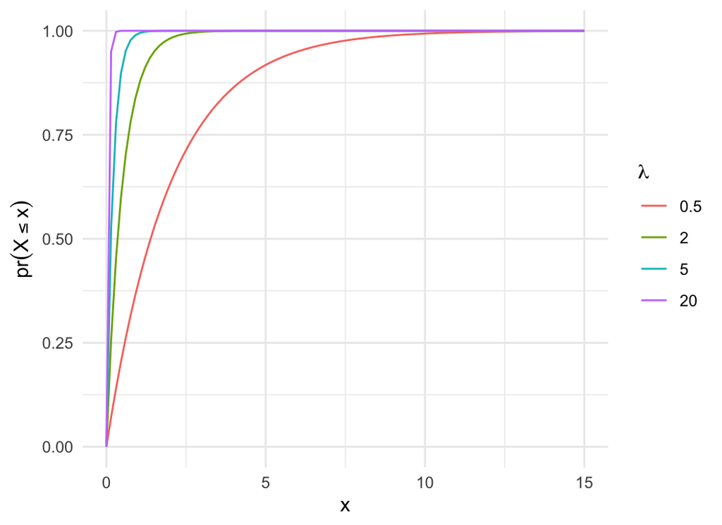

# Gamma distribution

- Expenential is a special case of Gamma where shape = 1
- Continuous, defined on $(0, \infty)$
- Highly generalised distribution, used in many cases for strictly positive variables
- Imagine observing a variable $X$, such that:
- $X_i \sim \mathrm{Poisson}(\lambda_i)$ (i.e., a mixture of Poisson distribtutions)
- $\lambda \sim \mathrm{Gamma}$
- It follows that $X \sim \mathrm{Negative Binomial}$

```r
dat = expand.grid(x=seq(0,15, length.out=100), shape=c(0.5, 4), rate = c(0.2, 2))
dat$pdf = with(dat, dgamma(x, shape=shape, rate = rate))
dat$cdf = with(dat, pgamma(x, shape=shape, rate = rate))
```

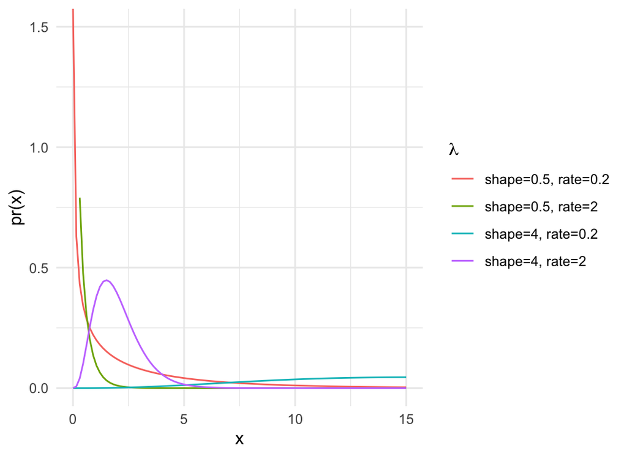

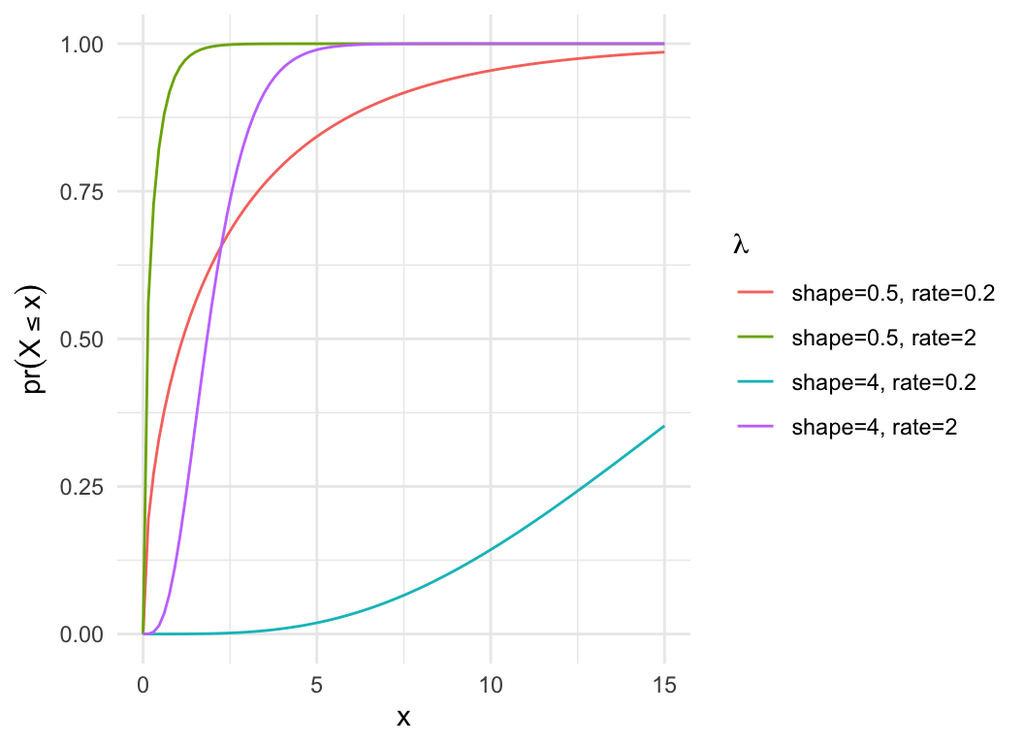

# Normal distribution

- Produced by additive processes (log-normal produced by multiplicative processes)
- Continuous, defined on $(-\infty, \infty)$

```r
dat = expand.grid(x=seq(-6,6, length.out=100), mu=0, sd = c(0.2, 1, 2))
dat$pdf = with(dat, dnorm(x, mu, sd))
dat$cdf = with(dat, pnorm(x, mu, sd))
```

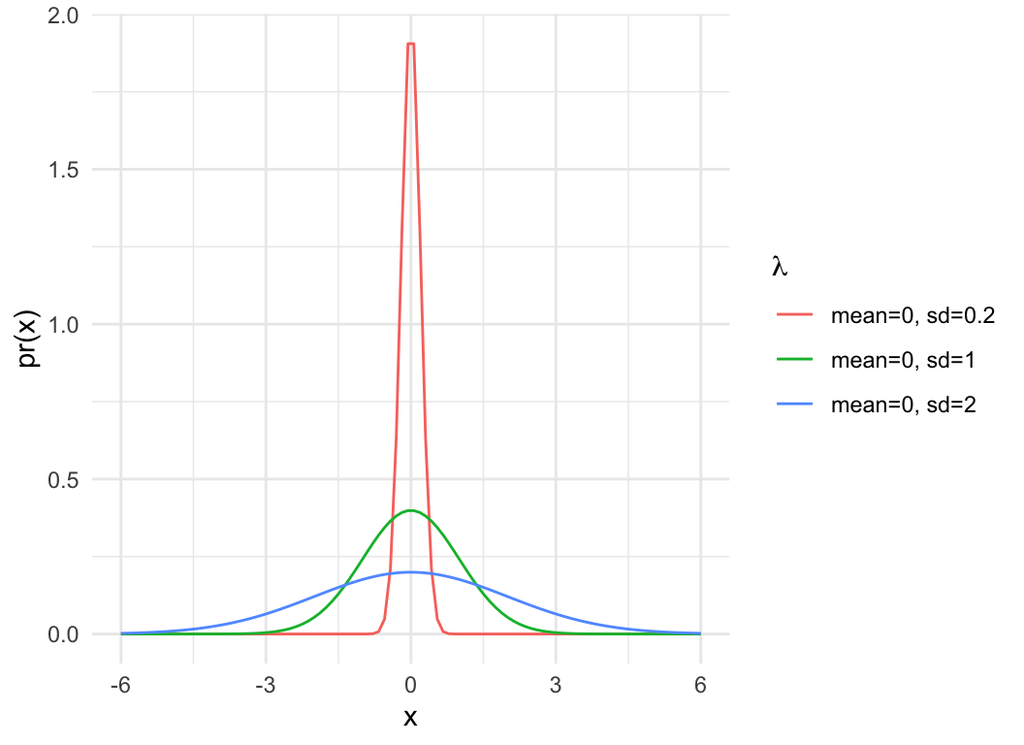

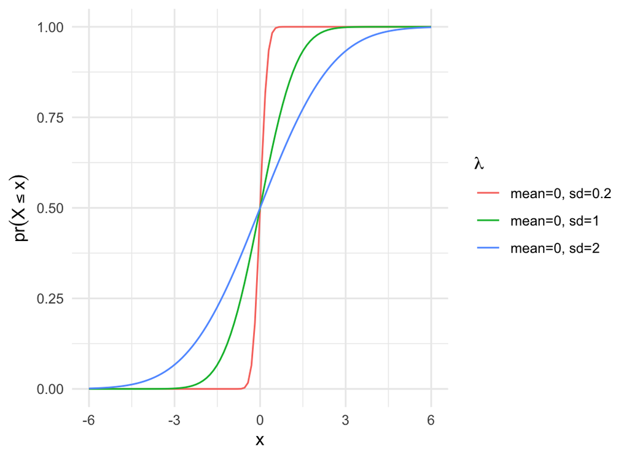

# Beta distribution

- Closely related to Binomial; often models the $p$ parameter for non-stationary Binomials
- Also used to model proportions
- Continuous, defined on $(0, 1)$

```r
dat = expand.grid(x=seq(0,1, length.out=100), alpha=c(0.5, 1, 2), beta = c(0.5, 1, 2))
dat$pdf = with(dat, dbeta(x, alpha, beta))
dat$cdf = with(dat, pbeta(x, alpha, beta))
```

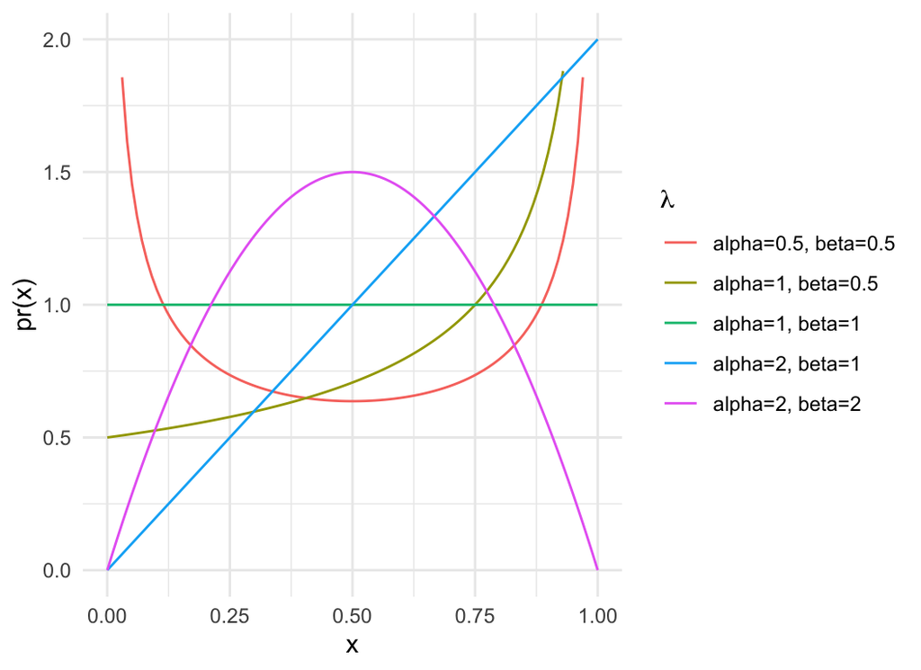

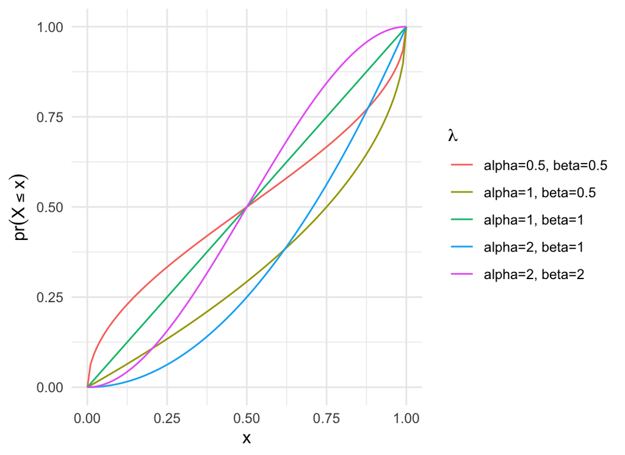

# Distribution functions

- A **probability density function** (PDF) is a function f(x) that:
  - is defined on an interval [a,b] (may be infinite)
  - is positive
  - is regular—one value of f(x) for every value of (x), and $\frac{df(x)}{dx}$ is finite
  - $\int_a^b f(x)dx = 1$
  - `d` functions in R (probability **d**ensity) – `dnorm`, `dgamma`, etc
  - For discrete distributions, called a **probability mass function** (PMF)
- Every PDF/PMF has a CDF
  - $F(x) = \int_a^x f(x)dx$
  - The probability of a value between $a$ and $x$
  - `p` functions in R (cumulative **p**robability) – `pnorm`, `pgamma`, etc